# An overview of the epistack package

Guillaume Devailly

23 juin 2021

#### Package

epistack 0.1.3

# 1 Introduction

The `epistack` package main objective is the visualizations of stacks of genomic tracks (such as, but not restricted to, ChIP-seq or DNA methyation data) centered at genomic regions of interest. `epistack` needs three different inputs:

- a genomic score objects, such as ChIP-seq coverage or DNA methylation values, provided as a `GRanges` (easily obtained from `bigwig` or `bam` files)
- a list of feature of interest, such as peaks or transcription start sites, provided as a `GRanges` (easily obtained from `gtf` or `bed` files)
- a score to sort the features, such as peak height of gene expression value

The following document will present two use cases: - plotting ChIP-seq signal at peaks to investigate peak quality - plotting ChIP-seq signal at gene promoters sorted according to gene expression to investigate the associations between an epigenetic mark and gene expression

Tips and other `epistack` functionalities will then be presented.

# 2 example data

To illustrate `epistack` fucntionalities, we will use example ChIP-seq data used in the [2016 CASME course](https://www.bioconductor.org/help/course-materials/2016/CSAMA/lab-5-chipseq/Epigenetics.html) “Basics of ChIP-seq data analysis” by Aleksandra Pekowska and Simon Anders. Data can be found in this github repository: https://github.com/Bioconductor/CSAMA2016/tree/master/lab-5-chipseq/EpigeneticsCSAMA/inst/bedfiles

There is now need to download the data as it can be directly parsed remotely. The data consists of 2 H3K27mac ChIP-seq replicates, an input control, and one list of peak for each replicates. It has been generated in mouse Embryonic Stem cells and been subseted to have only data from chromosome 6 to allow fast vignette generation (but `epistack` can deal with whole genome ChIP-seq data!).

```r
path_reads <- c(
    read1 = "https://raw.githubusercontent.com/Bioconductor/CSAMA2016/master/lab-5-chipseq/EpigeneticsCSAMA/inst/bedfiles/H3K27ac_rep1_filtered_ucsc_chr6.bed",
    read2 = "https://raw.githubusercontent.com/Bioconductor/CSAMA2016/master/lab-5-chipseq/EpigeneticsCSAMA/inst/bedfiles/H3K27ac_rep2_filtered_ucsc_chr6.bed",
    input = "https://raw.githubusercontent.com/Bioconductor/CSAMA2016/master/lab-5-chipseq/EpigeneticsCSAMA/inst/bedfiles/ES_input_filtered_ucsc_chr6.bed"
)

path_peaks <- c(
    peak1 = "https://raw.githubusercontent.com/Bioconductor/CSAMA2016/master/lab-5-chipseq/EpigeneticsCSAMA/inst/bedfiles/Rep1_peaks_ucsc_chr6.bed",
    peak2 = "https://raw.githubusercontent.com/Bioconductor/CSAMA2016/master/lab-5-chipseq/EpigeneticsCSAMA/inst/bedfiles/Rep2_peaks_ucsc_chr6.bed"
)
```

# 3 Example 1: ChIP-seq coverage at peaks

## 3.1 data loading

We first need to reads the peaks using *rtracklayer*:

```r
library(rtracklayer)
peaks <- lapply(path_peaks, import)
```

Peaks from each replicates can be merged using *GenomicRanges* `union()` function (loaded with *rtracklayer*). We then rescue peaks metadata, and compute a new `mean_score` that we use to arrange our peak list.

```r
merged_peaks <- union(peaks[[1]], peaks[[2]])

scores_rep1 <- double(length(merged_peaks))
scores_rep1[findOverlaps(peaks[[1]], merged_peaks, select = "first")] <- peaks[[1]]$score

scores_rep2 <- double(length(merged_peaks))
scores_rep2[findOverlaps(peaks[[2]], merged_peaks, select = "first")] <- peaks[[2]]$score

peak_type <- ifelse(
    scores_rep1 != 0 & scores_rep2 != 0, "Both", ifelse(
        scores_rep1 != 0, "Rep1 only", "Rep2 only"
    )
)

mcols(merged_peaks) <- DataFrame(scores_rep1, scores_rep2, peak_type)
merged_peaks$mean_scores <- apply((mcols(merged_peaks)[, c("scores_rep1", "scores_rep2")]), 1, mean)
merged_peaks <- merged_peaks[order(merged_peaks$mean_scores, decreasing = FALSE), ]
rm(scores_rep1, scores_rep2, peak_type)

merged_peaks
```

```
#> GRanges object with 3534 ranges and 4 metadata columns:
#>          seqnames              ranges strand | scores_rep1 scores_rep2   peak_type mean_scores
#>             <Rle>           <IRanges>  <Rle> |   <numeric>   <numeric> <character>   <numeric>
#>      [1]     chr6   96545103-96545640      * |       50.01        0.00   Rep1 only      25.005
#>      [2]     chr6   66963731-66964304      * |        0.00       50.03   Rep2 only      25.015
#>      [3]     chr6 100424986-100425605      * |       50.08        0.00   Rep1 only      25.040
#>      [4]     chr6 119142482-119143018      * |       50.09        0.00   Rep1 only      25.045
#>      [5]     chr6   94556781-94557433      * |        0.00       50.10   Rep2 only      25.050
#>      ...      ...                 ...    ... .         ...         ...         ...         ...
#>   [3530]     chr6 146579300-146583413      * |     3100.00     3100.00        Both     3100.00
#>   [3531]     chr6 148892322-148896273      * |     3100.00     3100.00        Both     3100.00
#>   [3532]     chr6   29296913-29298755      * |     3132.86     3100.00        Both     3116.43
#>   [3533]     chr6   56746391-56748809      * |     3217.75     3100.00        Both     3158.88
#>   [3534]     chr6   91638787-91646132      * |     3182.78     3203.04        Both     3192.91
#>   -------
#>   seqinfo: 1 sequence from an unspecified genome; no seqlengths
```

We then import the ChIP-seq reads. In the example datasets, they are provided as .bed files, but for ChIP-seq we recommand importing .bigwig coverage files. Bam files can also be imported using `GenomicAlignments::readGAlignment*()`.

```r
reads <- lapply(path_reads, import)
```

## 3.2 Generating coverage matrices

We now need to generate coverage matrices with ChIP-seq coverage signal summarize around each ChIP-seq peaks. Several tools exists to generate such coverage matrix. We will demonstrate the `normalizeToMatrix()` method from *EnrichedHeatmap*. Other alternatives include *Repitools*’ `featureScores()`, or *seqplots*’ `getPlotSetArray()`.

We will focus on the regions around peak centers, extended from +-5kb with a window size of 250 bp. We keep track of the extent of our region of interest in a `xlab` variable, and specify unique column names for each matrix.

When using ChIP-seq data from a bigwig file, use the `value_column` parameter of the `normalizeToMatrix()` function.

```r
summary(width(merged_peaks))
```

```
#>    Min. 1st Qu.  Median    Mean 3rd Qu.    Max.
#>   222.0   683.2   953.0  1373.5  1599.8 24604.0
```

```r
library(EnrichedHeatmap)

coverage_matrices <- lapply(
    reads,
    function(x) {
        normalizeToMatrix(
            x,
            resize(merged_peaks, width = 1, fix = "center"),
            extend = 5000, w = 250,
            mean_mode = "coverage"
        )
    }
)

colnames(coverage_matrices[[1]]) <- paste("Rep1" , seq_len(ncol(coverage_matrices[[1]])), sep = "_")
colnames(coverage_matrices[[2]]) <- paste("Rep2" , seq_len(ncol(coverage_matrices[[2]])), sep = "_")
colnames(coverage_matrices[[3]]) <- paste("Input", seq_len(ncol(coverage_matrices[[3]])), sep = "_")

xlabs <- c("-5kb", "peak center", "+5kb")
```

We then add each matrix to the `merged_peaks` object, and it should be ready for plotting.

```r
mcols(merged_peaks) <- cbind(
    mcols(merged_peaks),
    coverage_matrices[[1]],
    coverage_matrices[[2]],
    coverage_matrices[[3]]
)
```

## 3.3 Plotting

The `plotEpistack()` function will use the `merged_peaks` object to generate a complex representation of the ChIP-seq signals around the genomic feature of interests (here ChIP-seq peaks). It has quite an important number of parameters.

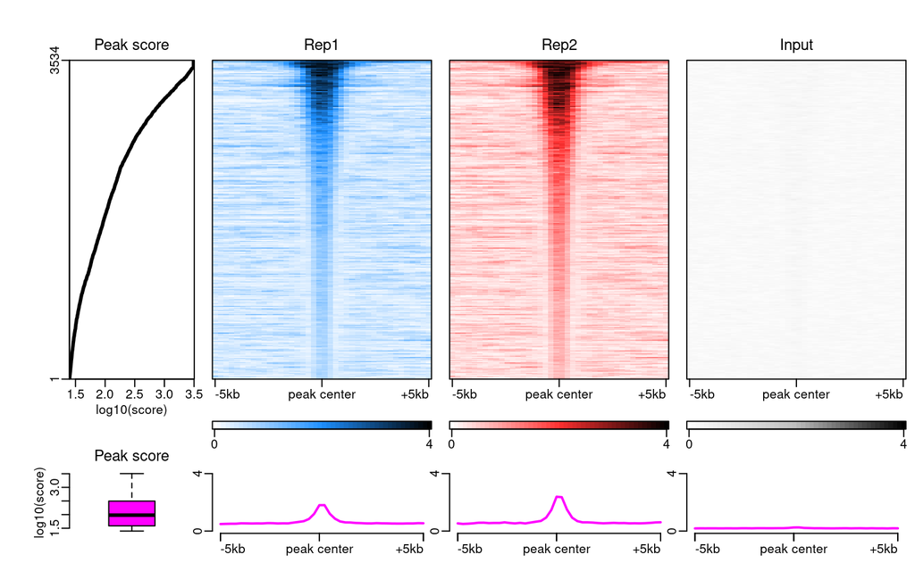

```r
library(epistack)

plotEpistack(
    merged_peaks,
    patterns = c("^Rep1_", "^Rep2_", "^Input_"),
    tints = c("dodgerblue", "firebrick1", "grey"),
    titles = c("Rep1", "Rep2" , "Input"),
    x_labels = xlabs,
    zlim = c(0, 4), ylim = c(0, 4),
    metric_col = "mean_scores", metric_title = "Peak score", metric_label = "log10(score)",
    metric_transfunc = function(x) log10(x),
    npix_height = 300
)
```

If a `bin` column is present in the epistack GRanges object, than it will be used to annotate the figure and to generate one average profile per bin in the lower panels. Here we use the `peak_type` as our bin column.

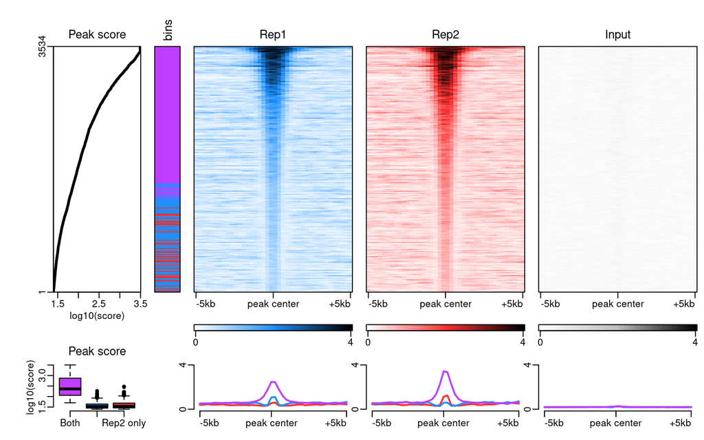

```r
merged_peaks$bin <- merged_peaks$peak_type

plotEpistack(
    merged_peaks,
    patterns = c("^Rep1_", "^Rep2_", "^Input_"),
    tints = c("dodgerblue", "firebrick1", "grey"),
    titles = c("Rep1", "Rep2" , "Input"),
    x_labels = xlabs,
    zlim = c(0, 4), ylim = c(0, 4),
    metric_col = "mean_scores", metric_title = "Peak score", metric_label = "log10(score)",
    metric_transfunc = function(x) log10(x),
    bin_palette = colorRampPalette(c("darkorchid1", "dodgerblue", "firebrick1")),
    npix_height = 300
)
```

It might be also interesting to sort on the bins first, and then on peak score:

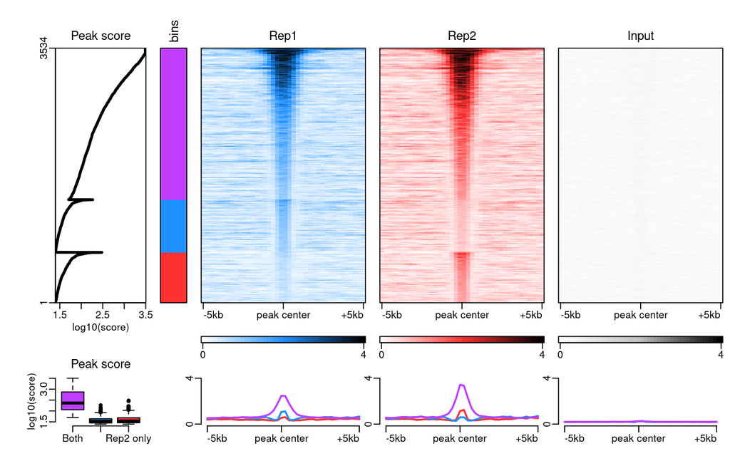

```r
merged_peaks <- merged_peaks[order(
  merged_peaks$bin, merged_peaks$mean_scores,
  decreasing = c(TRUE, FALSE), method = "radix"
), ]

plotEpistack(
    merged_peaks,
    patterns = c("^Rep1_", "^Rep2_", "^Input_"),
    tints = c("dodgerblue", "firebrick1", "grey"),
    titles = c("Rep1", "Rep2" , "Input"),
    x_labels = xlabs,
    zlim = c(0, 4), ylim = c(0, 4),
    metric_col = "mean_scores", metric_title = "Peak score", metric_label = "log10(score)",
    metric_transfunc = function(x) log10(x),
    bin_palette = colorRampPalette(c("darkorchid1", "dodgerblue", "firebrick1")),
    npix_height = 300
)
```

# 4 Example 2: DNA methylation levels and ChIP-seq coverage at gene promoters sorted according to expression levels

## 4.1 Obtaining the TSS coordinates

We now want to plot the epigenetic signals at gene promoters, or more precisely around gene Transcription Start Sites (TSS). TSS coordinate can be obtained from various sources. One can access the [Ensembl](https://www.ensembl.org/index.html) annotations using *biomaRt*, download a `.gtf` file and parse it using *rtracklayer*’s `import()`, or use *AnnotationHub* and *ensembldb*. It is however important to work with the same genome version has the one used to align the ChIP-seq reads.

For simplicity, we will use *EnrichedHeatmap* example data.

```r
load(
    system.file("extdata", "chr21_test_data.RData",
                package = "EnrichedHeatmap"),
    verbose = TRUE
)
```

```
#> Loading objects:
#>   H3K4me3
#>   cgi
#>   genes
#>   meth
#>   rpkm
```

```r
tss <- promoters(genes, upstream = 0, downstream = 1)
tss$gene_id <- names(tss)

tss
```

```
#> GRanges object with 720 ranges and 1 metadata column:
#>                      seqnames    ranges strand |            gene_id
#>                         <Rle> <IRanges>  <Rle> |        <character>
#>    ENSG00000141956.9    chr21  43299591      - |  ENSG00000141956.9
#>   ENSG00000141959.12    chr21  45719934      + | ENSG00000141959.12
#>    ENSG00000142149.4    chr21  33245628      + |  ENSG00000142149.4
#>   ENSG00000142156.10    chr21  47401651      + | ENSG00000142156.10
#>    ENSG00000142166.8    chr21  34696734      + |  ENSG00000142166.8
#>                  ...      ...       ...    ... .                ...
#>    ENSG00000270533.1    chr21  10476061      - |  ENSG00000270533.1
#>    ENSG00000270652.1    chr21  38315567      + |  ENSG00000270652.1
#>    ENSG00000270835.1    chr21  39577700      - |  ENSG00000270835.1
#>    ENSG00000271308.1    chr21  11169720      + |  ENSG00000271308.1
#>    ENSG00000271486.1    chr21  20993009      + |  ENSG00000271486.1
#>   -------
#>   seqinfo: 1 sequence from an unspecified genome; no seqlengths
```

## 4.2 Adding expression data to the TSS coordinates

Epistack can work with any units and any scores, not limited to expression data. Here we will use gene expression data from an RNA-seq experiment, in RPKM units, as it is the data format available in *EnrichedHeatmap* example dataset. To join the expression data to the TSS coordinates, we will use an *epistack* utility function `addMetricAndArrangeGRanges()`:

```r
expr <- data.frame(
    gene_id = names(rpkm),
    expr = rpkm
)

epidata <- addMetricAndArrangeGRanges(
    tss, expr,
    gr_key = "gene_id",
    order_key = "gene_id", order_value = "expr"
)

epidata
```

```
#> GRanges object with 720 ranges and 2 metadata columns:
#>                      seqnames    ranges strand |            gene_id      expr
#>                         <Rle> <IRanges>  <Rle> |        <character> <numeric>
#>    ENSG00000215447.3    chr21  46707967      + |  ENSG00000215447.3         0
#>    ENSG00000224747.1    chr21  45892399      - |  ENSG00000224747.1         0
#>    ENSG00000256715.1    chr21  14745386      - |  ENSG00000256715.1         0
#>    ENSG00000221335.1    chr21  19264028      + |  ENSG00000221335.1         0
#>    ENSG00000186977.2    chr21  31874435      - |  ENSG00000186977.2         0
#>                  ...      ...       ...    ... .                ...       ...
#>   ENSG00000142168.10    chr21  33031935      + | ENSG00000142168.10   97.5167
#>    ENSG00000183255.7    chr21  46293752      - |  ENSG00000183255.7  131.7230
#>   ENSG00000142192.16    chr21  27543446      - | ENSG00000142192.16  137.3838
#>    ENSG00000160307.5    chr21  48025121      - |  ENSG00000160307.5  145.4498
#>    ENSG00000198618.4    chr21  20230097      + |  ENSG00000198618.4  461.0990
#>   -------
#>   seqinfo: 1 sequence from an unspecified genome; no seqlengths
```

We creat 5 bins of genes of equal sizes depending on the expression levels, with *epistack* utility function `addBins()`:

```r
epidata <- epistack:::addBins(epidata, nbins = 5)
epidata
```

```
#> GRanges object with 720 ranges and 3 metadata columns:
#>                      seqnames    ranges strand |            gene_id      expr       bin
#>                         <Rle> <IRanges>  <Rle> |        <character> <numeric> <numeric>
#>    ENSG00000215447.3    chr21  46707967      + |  ENSG00000215447.3         0         1
#>    ENSG00000224747.1    chr21  45892399      - |  ENSG00000224747.1         0         1
#>    ENSG00000256715.1    chr21  14745386      - |  ENSG00000256715.1         0         1
#>    ENSG00000221335.1    chr21  19264028      + |  ENSG00000221335.1         0         1
#>    ENSG00000186977.2    chr21  31874435      - |  ENSG00000186977.2         0         1
#>                  ...      ...       ...    ... .                ...       ...       ...
#>   ENSG00000142168.10    chr21  33031935      + | ENSG00000142168.10   97.5167         5
#>    ENSG00000183255.7    chr21  46293752      - |  ENSG00000183255.7  131.7230         5
#>   ENSG00000142192.16    chr21  27543446      - | ENSG00000142192.16  137.3838         5
#>    ENSG00000160307.5    chr21  48025121      - |  ENSG00000160307.5  145.4498         5
#>    ENSG00000198618.4    chr21  20230097      + |  ENSG00000198618.4  461.0990         5
#>   -------
#>   seqinfo: 1 sequence from an unspecified genome; no seqlengths
```

## 4.3 Extracting the epigenetic signals

As previously described, we will use *EnrichedHeatmap*’s `normalizeToMatrix()` function to extract the signals, rename the signal colmun names, and add them to the epidata GRanges object:

```r
methstack <- normalizeToMatrix(
    meth, tss, value_column = "meth",
    extend = 5000, w = 250, mean_mode = "absolute"
)
colnames(methstack) <- paste("meth" , seq_len(ncol(methstack)), sep = "_")

h3k4me3stack <- normalizeToMatrix(
    H3K4me3, tss, value_column = "coverage",
    extend = 5000, w = 250, mean_mode = "coverage"
)
colnames(h3k4me3stack) <- paste("H3K4me3", seq_len(ncol(h3k4me3stack)), sep = "_")

mcols(epidata) <- cbind(
    mcols(epidata), methstack, h3k4me3stack
)
```

## 4.4 Epistack plotting

The `epidata` GRanges object is now ready to plot:

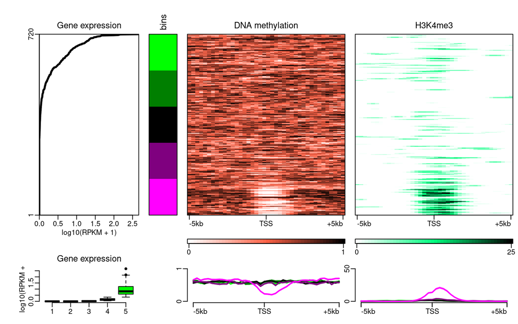

```r
plotEpistack(
    epidata,
    patterns = c("^meth_", "^H3K4me3"),
    tints = c("tomato", "springgreen"),
    titles = c("DNA methylation", "H3K4me3"),
    zlim = list(c(0, 1), c(0, 25)), ylim = list(c(0, 1), c(0, 50)),
    x_labels = c("-5kb", "TSS", "+5kb"),
    metric_col = "expr", metric_title = "Gene expression",
    metric_label = "log10(RPKM + 1)",
    metric_transfunc = function(x) log10(x + 1),
    npix_height = 300
)
```